# Part I - (ProsperLoanData)

## by (Adease Moyosore Odutayo)

## Introduction

> Introducing of dataset.

> The dataset consist of eighty one(81) columns and one hundred and thirteen thousand and nine hundred thirty seven rows. It comprises mainly loan information of customer, defaulters, compliance, borrower rate (or interest rate), current loan status, borrower income, and many others.

## Preliminary Wrangling

###### Loading of the dataset.

- Using the pandas read function to call our data set

### What is the structure of your dataset?

> 113937 row and 81 columns

### What is/are the main feature(s) of interest in your dataset?

> The main featuers of inerest is LoanStatus of prosperLoanData to known if borrowers payment of loan is higher than outstanding, and to know if compliance is increasing or declining

### What features in the dataset do you think will help support your investigation into your feature(s) of interest?

> The Variables that will help in investigating this dataset, are LoanStatus, ListingCategory (numeric), IsBorrowerHomeowner, Occupation,IncomeRange, ProsperScore, BorrowerAPR,BorrowerRate,IsBorrowerHomeowner

## Univariate Exploration

> In this section, investigate distributions of individual variables. If you see unusual points or outliers, take a deeper look to clean things up and prepare yourself to look at relationships between variables.

###### To know the counts of variables in LoanStatus column

#### Using seaborn heatmap function to visualize the column that has null value

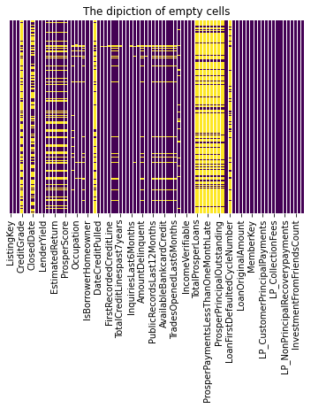

#### Columns to drop

###### Observation

> After droping some variables we can see that our heatmap visualization is more cleaner, thou we still have some empty cells, the empty cells means completed in the LoanStatus column.

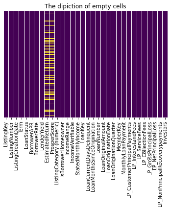

[figure not shown]

##### Creating function to avoid repetitive code

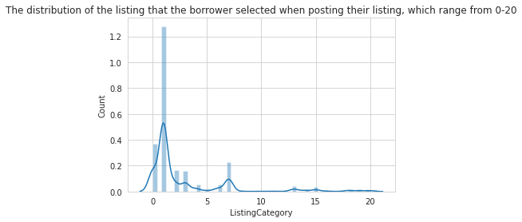

##### From our graph we can see that those with home and without home are approximately almostly the same, we can draw insight from it, these as also contributed to the slow payment of loan.

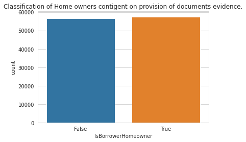

#### The income range gives a full insight why we have less people who are complying, we can see that the high income earners bar complied less to loan payment compared to low borrowers who have a high rate rate of compliance, we can conclude these as resulted in higher current loan and more defaulters.

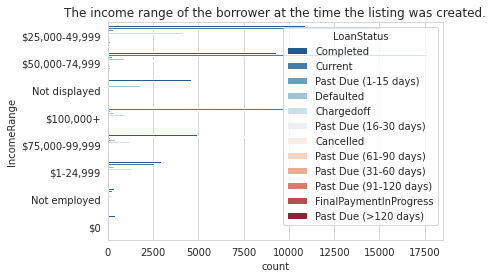

#### Using boxplot we can know the summary of how the money was spent, we can see that most of the loan were collected mostly for consumables, expenses, and not asset that can generate revenue, and the outlier just show that we have fewer of those categories

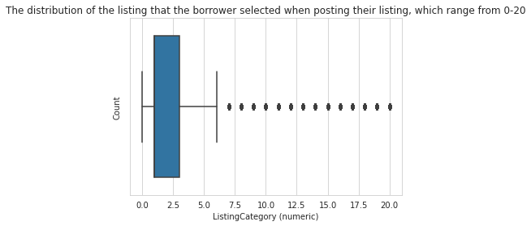

#### Comparing our distribution and range we can see that usage of the loan collected from prosper was used more for expenses, rather than revenue

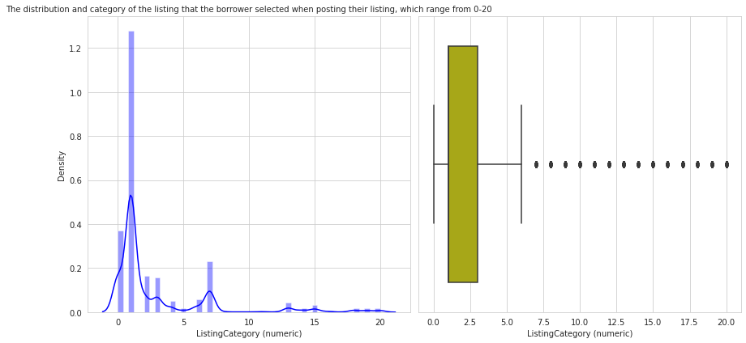

### Discuss the distribution(s) of your variable(s) of interest. Were there any unusual points? Did you need to perform any transformations?

> There was no need for transformation of of the datatyes, formats and others!

## Bivariate Exploration

> In this section, investigate relationships between pairs of variables in your data. Make sure the variables that you cover here have been introduced in some fashion in the previous section (univariate exploration).

###### Observation

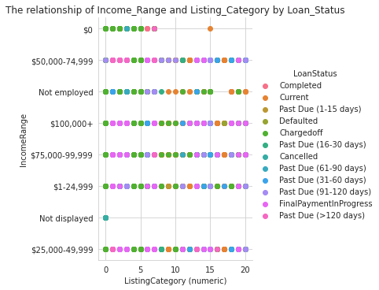

###### Creating function to avoid repetitive code

###### observation

> we can see that we have more of 0-2 i.e (0 - Not Available, 1 - Debt Consolidation, 2 - Home Improvement) category who have completly paid their loan, and goes down that way, and a noticeable incident is the cancelled status whose loan debt as been cancelled falls between -1 to +1

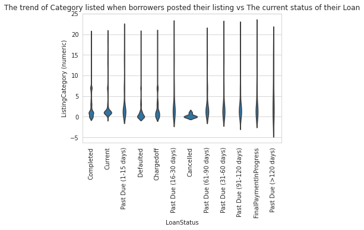

###### Observation

> from our boxplot we understand that the best risk score exceeds average inthe completed loanStatus, compared to others, the majority are evenly shared between the quartile one and quartile three. which invariable means that majority of the best risk score complied to payment.

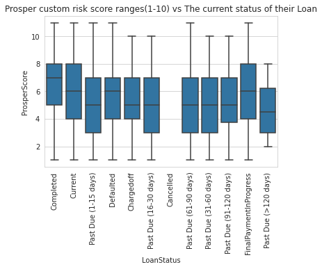

##### Observation

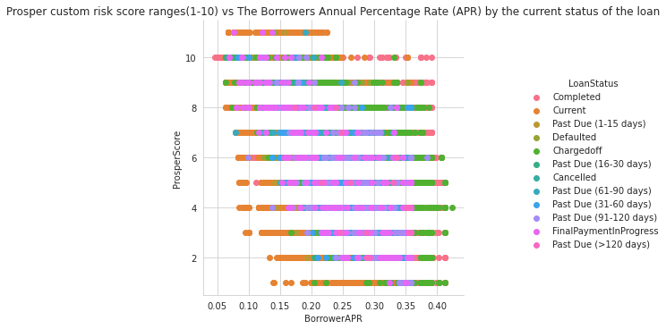

##### Observation

> We can see simlar trend with the Borrower Interest rate the higher the interest rate the higher likely-hood of borrowers defaulting.

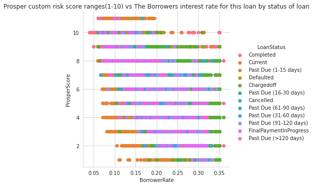

#### Observation

> The graph shows that the majority of people that were able to complete their payment where people with low return compare to those who had high return. this indicates that the defaulters are majorly high risk borrowers with high return

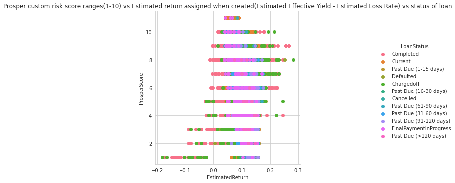

#### Observation

> The graph shows us that only about three ListingCategories where able to pay-off their loan, the first the information is not know, second, some StudentUse with poor risk paid their loan ahead of those who with best risk rate and, lastly Cosmetic Procedures had two stage of risk rating who have completed their loan payment(from the best risk rate and Low risk rate)

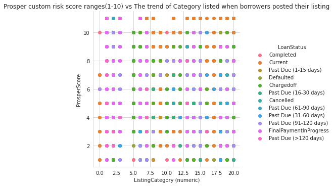

### Talk about some of the relationships you observed in this part of the investigation. How did the feature(s) of interest vary with other features in the dataset?

> What I observe is that in the prosperscore and ListingCategory the listingCategory with worst risk rate completed their loan payment compare to those with worst risk rating in the prosperScore vs BorrowerAPR, in other words the best risk rating in the prosperScore vs BorrowerAPR had higher borrowers that completed their payment

### Did you observe any interesting relationships between the other features (not the main feature(s) of interest)?

> The most interesting relationship is the Prosperscore, where we can see that majority of the best risk rating where the once that completed loan, compare to the worst risk rating!

## Multivariate Exploration

> Create plots of three or more variables to investigate your data even further. Make sure that your investigations are justified, and follow from your work in the previous sections.

###### This give us an overview of the relationships and trend which we have seen earlier in my data exploration from univariate, bivariate, and multivariate

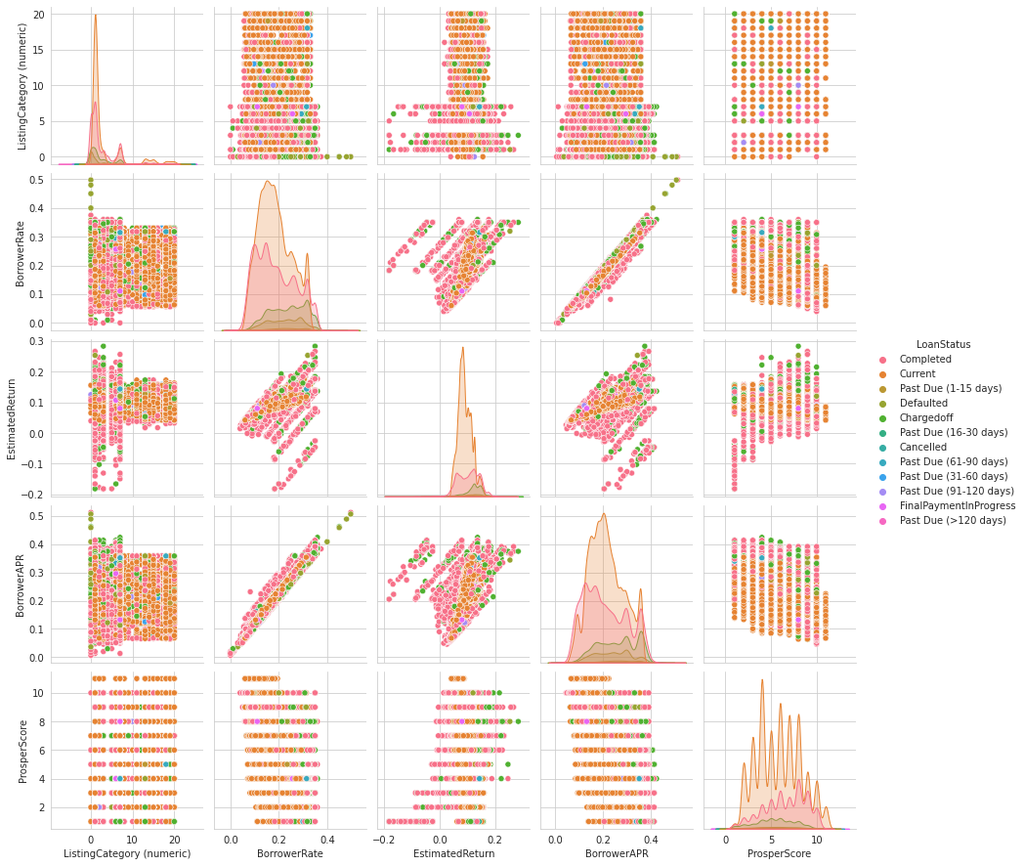

###### Observation

- we can see that we have more of 0-2.5 which is indicated with yellow on the category level who have completed their payment, and next is the light green which shows on the category label(2.5-6.0), and and just one which is between 12.5-15.0, with a good risk score has completed their loan payment, and largely we have majority of the yellow who have defaulted all through the loan status.

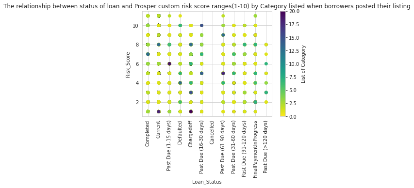

###### Observation

- In the monthly and yearly interest rate we can see we have more people who completed their payment at the low interest rate and spread accross almost evenly upward the interest rate. and those currently owing are between 0.06 to 0.37 along the interest rate axis.

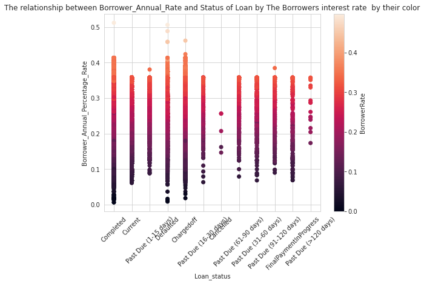

###### Observation

- Our plots shows that our graph is positive graph, and there is growth in payment, and one payment at the pick father away from the rest, there call for further investigation. we have more deflaulter at the pick of our graph.

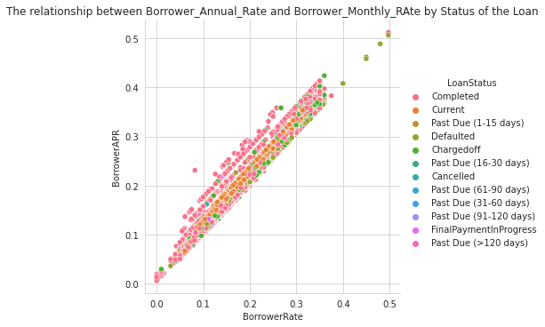

### Talk about some of the relationships you observed in this part of the investigation. Were there features that strengthened each other in terms of looking at your feature(s) of interest?

> We can see that there is positive reponse to payment of loans, thou higher at the lower rate and risk score, this tells us why we still have more current payment than completed payment !

### Were there any interesting or surprising interactions between features?

> The surprising interaction is that we have some completed payment which are father from the other, which calls for further investigation, and these investigation will give us more understanding about why we have more completed, current, and defaulters at the worst risk and interest rate.!

## Conclusions

> The steps taking to understand the ProsperLoan Data Set where a little beat tasking. I have to use the pandas read function to call the data set, then use the shape function to know the rows and columns, after which i use the heatmap function with the isnull parameters to know which variable has more empty cells, knowing this, i use the drop function to drop some columns, that where having a lot of empty cells and not useful for the explanatory data visualization of this data_set.

> The main findings are as follows:

> The compliance of loan payment is positive, thou not glaring if one only look at it using the countplot, one will think the company is operating at lost, but using the relationship plot we can see that there is positive compliance, with only few distant figures which needs further investigation.